# Risk Factor Analysis

## Outcome Variable

**Outcome Variable:** whz

## Predictor Variables

**Intervention Variable:** meducyrs

**Adjustment Set:**

- arm
- W_mage
- feducyrs
- hhwealth_quart
- W_mhtcm
- W_mwtkg
- W_mbmi
- W_gagebrth
- W_birthwt
- W_birthlen
- single
- W_nrooms
- impsan
- delta_W_mage
- delta_feducyrs
- delta_hhwealth_quart
- delta_W_mhtcm
- delta_W_mwtkg
- delta_W_mbmi
- delta_W_gagebrth
- delta_W_birthwt
- delta_W_birthlen
- delta_single
- delta_W_nrooms
- delta_impsan

## Stratifying Variables

The analysis was stratified on these variable(s):

- agecat
- studyid
- country

## Data Summary

| agecat | studyid | country | meducyrs | n_cell | n |
| --- | --- | --- | --- | --- | --- |
| Birth | CMC-V-BCS-2002 | INDIA | High | 49 | 86 |
| Birth | CMC-V-BCS-2002 | INDIA | Low | 15 | 86 |
| Birth | CMC-V-BCS-2002 | INDIA | Medium | 22 | 86 |
| Birth | COHORTS | GUATEMALA | High | 157 | 748 |
| Birth | COHORTS | GUATEMALA | Low | 344 | 748 |
| Birth | COHORTS | GUATEMALA | Medium | 247 | 748 |
| Birth | COHORTS | INDIA | High | 656 | 4879 |
| Birth | COHORTS | INDIA | Low | 1602 | 4879 |
| Birth | COHORTS | INDIA | Medium | 2621 | 4879 |
| Birth | COHORTS | PHILIPPINES | High | 1128 | 2899 |
| Birth | COHORTS | PHILIPPINES | Low | 838 | 2899 |
| Birth | COHORTS | PHILIPPINES | Medium | 933 | 2899 |
| Birth | EE | PAKISTAN | High | 5 | 177 |
| Birth | EE | PAKISTAN | Low | 156 | 177 |
| Birth | EE | PAKISTAN | Medium | 16 | 177 |
| Birth | GMS-Nepal | NEPAL | High | 81 | 639 |
| Birth | GMS-Nepal | NEPAL | Low | 444 | 639 |
| Birth | GMS-Nepal | NEPAL | Medium | 114 | 639 |
| Birth | IRC | INDIA | High | 101 | 343 |
| Birth | IRC | INDIA | Low | 126 | 343 |
| Birth | IRC | INDIA | Medium | 116 | 343 |
| Birth | JiVitA-3 | BANGLADESH | High | 5631 | 17988 |
| Birth | JiVitA-3 | BANGLADESH | Low | 6897 | 17988 |
| Birth | JiVitA-3 | BANGLADESH | Medium | 5460 | 17988 |
| Birth | JiVitA-4 | BANGLADESH | High | 805 | 2391 |
| Birth | JiVitA-4 | BANGLADESH | Low | 829 | 2391 |
| Birth | JiVitA-4 | BANGLADESH | Medium | 757 | 2391 |
| Birth | MAL-ED | BANGLADESH | High | 64 | 175 |
| Birth | MAL-ED | BANGLADESH | Low | 60 | 175 |
| Birth | MAL-ED | BANGLADESH | Medium | 51 | 175 |

[output cut: 183 more lines]

The following strata were considered:

- agecat: 24 months, studyid: CMC-V-BCS-2002, country: INDIA
- agecat: 24 months, studyid: COHORTS, country: GUATEMALA
- agecat: 24 months, studyid: COHORTS, country: INDIA
- agecat: 24 months, studyid: COHORTS, country: PHILIPPINES
- agecat: 24 months, studyid: EE, country: PAKISTAN
- agecat: 24 months, studyid: GMS-Nepal, country: NEPAL
- agecat: 24 months, studyid: IRC, country: INDIA
- agecat: 24 months, studyid: JiVitA-3, country: BANGLADESH
- agecat: 24 months, studyid: JiVitA-4, country: BANGLADESH
- agecat: 24 months, studyid: LCNI-5, country: MALAWI
- agecat: 24 months, studyid: MAL-ED, country: BANGLADESH
- agecat: 24 months, studyid: MAL-ED, country: BRAZIL
- agecat: 24 months, studyid: MAL-ED, country: INDIA
- agecat: 24 months, studyid: MAL-ED, country: NEPAL
- agecat: 24 months, studyid: MAL-ED, country: PERU
- agecat: 24 months, studyid: MAL-ED, country: SOUTH AFRICA
- agecat: 24 months, studyid: MAL-ED, country: TANZANIA, UNITED REPUBLIC OF
- agecat: 24 months, studyid: NIH-Birth, country: BANGLADESH
- agecat: 24 months, studyid: NIH-Crypto, country: BANGLADESH
- agecat: 24 months, studyid: PROBIT, country: BELARUS
- agecat: 24 months, studyid: PROVIDE, country: BANGLADESH
- agecat: 24 months, studyid: TanzaniaChild2, country: TANZANIA, UNITED REPUBLIC OF
- agecat: 24 months, studyid: ZVITAMBO, country: ZIMBABWE
- agecat: 6 months, studyid: CMC-V-BCS-2002, country: INDIA
- agecat: 6 months, studyid: COHORTS, country: GUATEMALA
- agecat: 6 months, studyid: COHORTS, country: INDIA
- agecat: 6 months, studyid: COHORTS, country: PHILIPPINES
- agecat: 6 months, studyid: EE, country: PAKISTAN
- agecat: 6 months, studyid: GMS-Nepal, country: NEPAL
- agecat: 6 months, studyid: Guatemala BSC, country: GUATEMALA
- agecat: 6 months, studyid: IRC, country: INDIA
- agecat: 6 months, studyid: JiVitA-3, country: BANGLADESH
- agecat: 6 months, studyid: JiVitA-4, country: BANGLADESH
- agecat: 6 months, studyid: LCNI-5, country: MALAWI
- agecat: 6 months, studyid: MAL-ED, country: BANGLADESH
- agecat: 6 months, studyid: MAL-ED, country: BRAZIL
- agecat: 6 months, studyid: MAL-ED, country: INDIA
- agecat: 6 months, studyid: MAL-ED, country: NEPAL
- agecat: 6 months, studyid: MAL-ED, country: PERU
- agecat: 6 months, studyid: MAL-ED, country: SOUTH AFRICA
- agecat: 6 months, studyid: MAL-ED, country: TANZANIA, UNITED REPUBLIC OF
- agecat: 6 months, studyid: NIH-Birth, country: BANGLADESH
- agecat: 6 months, studyid: NIH-Crypto, country: BANGLADESH
- agecat: 6 months, studyid: PROBIT, country: BELARUS
- agecat: 6 months, studyid: PROVIDE, country: BANGLADESH
- agecat: 6 months, studyid: SAS-CompFeed, country: INDIA
- agecat: 6 months, studyid: SAS-FoodSuppl, country: INDIA
- agecat: 6 months, studyid: TanzaniaChild2, country: TANZANIA, UNITED REPUBLIC OF
- agecat: 6 months, studyid: ZVITAMBO, country: ZIMBABWE
- agecat: Birth, studyid: CMC-V-BCS-2002, country: INDIA
- agecat: Birth, studyid: COHORTS, country: GUATEMALA
- agecat: Birth, studyid: COHORTS, country: INDIA
- agecat: Birth, studyid: COHORTS, country: PHILIPPINES
- agecat: Birth, studyid: EE, country: PAKISTAN
- agecat: Birth, studyid: GMS-Nepal, country: NEPAL
- agecat: Birth, studyid: IRC, country: INDIA
- agecat: Birth, studyid: JiVitA-3, country: BANGLADESH
- agecat: Birth, studyid: JiVitA-4, country: BANGLADESH
- agecat: Birth, studyid: MAL-ED, country: BANGLADESH
- agecat: Birth, studyid: MAL-ED, country: BRAZIL
- agecat: Birth, studyid: MAL-ED, country: INDIA
- agecat: Birth, studyid: MAL-ED, country: NEPAL
- agecat: Birth, studyid: MAL-ED, country: PERU
- agecat: Birth, studyid: MAL-ED, country: SOUTH AFRICA
- agecat: Birth, studyid: MAL-ED, country: TANZANIA, UNITED REPUBLIC OF
- agecat: Birth, studyid: NIH-Birth, country: BANGLADESH
- agecat: Birth, studyid: NIH-Crypto, country: BANGLADESH
- agecat: Birth, studyid: PROBIT, country: BELARUS
- agecat: Birth, studyid: PROVIDE, country: BANGLADESH
- agecat: Birth, studyid: SAS-CompFeed, country: INDIA
- agecat: Birth, studyid: ZVITAMBO, country: ZIMBABWE

### Dropped Strata

Some strata were dropped due to rare outcomes:

- agecat: 24 months, studyid: TanzaniaChild2, country: TANZANIA, UNITED REPUBLIC OF

## Methods Detail

We’re interested in the causal parameters $E[Y_a]$ for all values of $a \in \mathcal{A}$. These parameters represent the mean outcome if, possibly contrary to fact, we intervened to set all units to have $A=a$. Under the randomization and positivity assumptions, these are identified by the statistical parameters $\psi_a=E_W[E_{Y|A,W}(Y|A=a,W)]$. In addition, we’re interested in the mean of $Y$, $E[Y]$ under no intervention (the observed mean). We will estimate these parameters by using SuperLearner to fit the relevant likelihood factors – $E_{Y|A,W}(Y|A=a,W)$ and $p(A=a|W)$, and then updating our likelihood fit using a joint TMLE.

For unadjusted analyses ($W=\{\}$), initial likelihoods were estimated using Lrnr_glm to estimate the simple $E(Y|A)$ and Lrnr_mean to estimate $p(A)$. For adjusted analyses, a small library containing Lrnr_glmnet, Lrnr_xgboost, and Lrnr_mean was used.

Having estimated these parameters, we will then use the delta method to estimate relative risks and attributable risks relative to a prespecified baseline level of $A$.

# Results Detail

## Results Plots

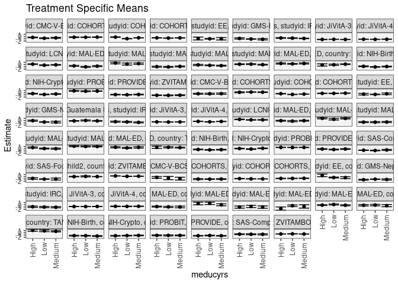

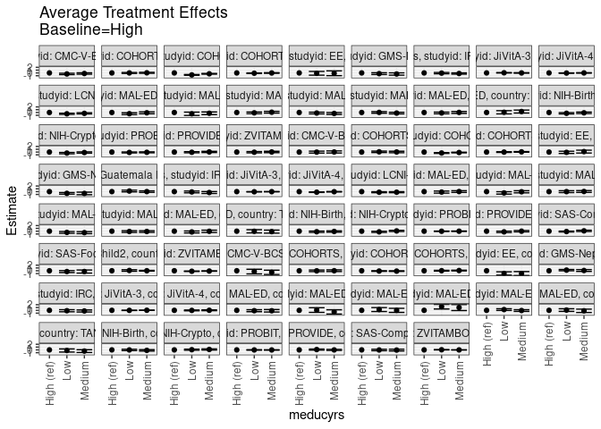

[figure not shown]

## Results Table

### Parameter: TSM

| agecat | studyid | country | intervention_level | baseline_level | estimate | ci_lower | ci_upper |
| --- | --- | --- | --- | --- | --- | --- | --- |
| Birth | CMC-V-BCS-2002 | INDIA | High | NA | -0.2876995 | -0.6911898 | 0.1157909 |
| Birth | CMC-V-BCS-2002 | INDIA | Low | NA | -0.5806304 | -1.3064586 | 0.1451979 |
| Birth | CMC-V-BCS-2002 | INDIA | Medium | NA | -0.8459187 | -1.4877409 | -0.2040965 |
| Birth | COHORTS | GUATEMALA | High | NA | -1.0407198 | -1.2938982 | -0.7875414 |
| Birth | COHORTS | GUATEMALA | Low | NA | -1.0628625 | -1.2061904 | -0.9195346 |
| Birth | COHORTS | GUATEMALA | Medium | NA | -1.0263026 | -1.2117847 | -0.8408205 |
| Birth | COHORTS | INDIA | High | NA | -0.8509822 | -0.9496661 | -0.7522984 |
| Birth | COHORTS | INDIA | Low | NA | -0.9578838 | -1.0280687 | -0.8876989 |
| Birth | COHORTS | INDIA | Medium | NA | -0.9756957 | -1.0221312 | -0.9292602 |
| Birth | COHORTS | PHILIPPINES | High | NA | -0.7657425 | -0.8541783 | -0.6773067 |
| Birth | COHORTS | PHILIPPINES | Low | NA | -0.7445432 | -0.8437621 | -0.6453242 |
| Birth | COHORTS | PHILIPPINES | Medium | NA | -0.6902363 | -0.7850755 | -0.5953971 |
| Birth | EE | PAKISTAN | High | NA | 0.6080000 | 0.0422458 | 1.1737542 |
| Birth | EE | PAKISTAN | Low | NA | -0.3569551 | -0.5627099 | -0.1512003 |
| Birth | EE | PAKISTAN | Medium | NA | -0.3968750 | -0.8274988 | 0.0337488 |
| Birth | GMS-Nepal | NEPAL | High | NA | -1.3287333 | -1.5361359 | -1.1213308 |
| Birth | GMS-Nepal | NEPAL | Low | NA | -1.0951679 | -1.2031851 | -0.9871508 |
| Birth | GMS-Nepal | NEPAL | Medium | NA | -1.2360622 | -1.4977758 | -0.9743487 |
| Birth | IRC | INDIA | High | NA | -0.8836736 | -1.1796267 | -0.5877206 |
| Birth | IRC | INDIA | Low | NA | -1.0263292 | -1.3026915 | -0.7499669 |
| Birth | IRC | INDIA | Medium | NA | -1.1163842 | -1.3843368 | -0.8484317 |
| Birth | JiVitA-3 | BANGLADESH | High | NA | -0.7951473 | -0.8414925 | -0.7488022 |
| Birth | JiVitA-3 | BANGLADESH | Low | NA | -0.8089807 | -0.8451803 | -0.7727810 |
| Birth | JiVitA-3 | BANGLADESH | Medium | NA | -0.7673697 | -0.8027860 | -0.7319534 |
| Birth | JiVitA-4 | BANGLADESH | High | NA | -0.6950309 | -0.7999693 | -0.5900924 |
| Birth | JiVitA-4 | BANGLADESH | Low | NA | -0.7190465 | -0.8226023 | -0.6154907 |
| Birth | JiVitA-4 | BANGLADESH | Medium | NA | -0.6790802 | -0.7758382 | -0.5823222 |
| Birth | MAL-ED | BANGLADESH | High | NA | -0.8113691 | -1.0254533 | -0.5972848 |
| Birth | MAL-ED | BANGLADESH | Low | NA | -0.9460578 | -1.2242552 | -0.6678604 |
| Birth | MAL-ED | BANGLADESH | Medium | NA | -0.9760919 | -1.3626400 | -0.5895439 |

[output cut: 180 more lines]

### Parameter: E(Y)

| agecat | studyid | country | intervention_level | baseline_level | estimate | ci_lower | ci_upper |
| --- | --- | --- | --- | --- | --- | --- | --- |
| Birth | CMC-V-BCS-2002 | INDIA | NA | NA | -0.4648256 | -0.7643210 | -0.1653302 |
| Birth | COHORTS | GUATEMALA | NA | NA | -1.0590508 | -1.1604735 | -0.9576281 |
| Birth | COHORTS | INDIA | NA | NA | -0.9831277 | -1.0164986 | -0.9497568 |
| Birth | COHORTS | PHILIPPINES | NA | NA | -0.7427251 | -0.7890855 | -0.6963647 |
| Birth | EE | PAKISTAN | NA | NA | -0.3333051 | -0.5209779 | -0.1456323 |
| Birth | GMS-Nepal | NEPAL | NA | NA | -1.1182629 | -1.2060675 | -1.0304584 |
| Birth | IRC | INDIA | NA | NA | -1.0105831 | -1.1973019 | -0.8238643 |
| Birth | JiVitA-3 | BANGLADESH | NA | NA | -0.7779831 | -0.7969771 | -0.7589891 |
| Birth | JiVitA-4 | BANGLADESH | NA | NA | -0.6895483 | -0.7419864 | -0.6371102 |
| Birth | MAL-ED | BANGLADESH | NA | NA | -0.9109143 | -1.0715205 | -0.7503080 |
| Birth | MAL-ED | BRAZIL | NA | NA | 0.4029032 | 0.0896793 | 0.7161272 |
| Birth | MAL-ED | INDIA | NA | NA | -0.9021053 | -1.2132997 | -0.5909108 |
| Birth | MAL-ED | NEPAL | NA | NA | -0.7791667 | -1.1649642 | -0.3933692 |
| Birth | MAL-ED | PERU | NA | NA | -0.0520175 | -0.1725298 | 0.0684947 |
| Birth | MAL-ED | SOUTH AFRICA | NA | NA | -0.1925833 | -0.4053570 | 0.0201904 |
| Birth | MAL-ED | TANZANIA, UNITED REPUBLIC OF | NA | NA | 0.7997938 | 0.5930740 | 1.0065137 |
| Birth | NIH-Birth | BANGLADESH | NA | NA | -1.3499217 | -1.4444634 | -1.2553801 |
| Birth | NIH-Crypto | BANGLADESH | NA | NA | -1.2441513 | -1.3281130 | -1.1601897 |
| Birth | PROBIT | BELARUS | NA | NA | -1.1491782 | -1.3593933 | -0.9389630 |
| Birth | PROVIDE | BANGLADESH | NA | NA | -1.2984586 | -1.3752758 | -1.2216415 |
| Birth | SAS-CompFeed | INDIA | NA | NA | -0.6700453 | -0.8474950 | -0.4925957 |
| Birth | ZVITAMBO | ZIMBABWE | NA | NA | -0.5152927 | -0.5411678 | -0.4894176 |
| 6 months | CMC-V-BCS-2002 | INDIA | NA | NA | -0.5026766 | -0.6536848 | -0.3516685 |
| 6 months | COHORTS | GUATEMALA | NA | NA | 0.1972718 | 0.1253735 | 0.2691700 |
| 6 months | COHORTS | INDIA | NA | NA | -0.7006307 | -0.7314213 | -0.6698400 |
| 6 months | COHORTS | PHILIPPINES | NA | NA | -0.2938433 | -0.3352064 | -0.2524802 |
| 6 months | EE | PAKISTAN | NA | NA | -0.7785977 | -0.8934940 | -0.6637013 |
| 6 months | GMS-Nepal | NEPAL | NA | NA | -0.6087819 | -0.6949591 | -0.5226048 |
| 6 months | Guatemala BSC | GUATEMALA | NA | NA | -0.0568833 | -0.1722874 | 0.0585208 |
| 6 months | IRC | INDIA | NA | NA | -0.5989297 | -0.7344491 | -0.4634104 |
| 6 months | JiVitA-3 | BANGLADESH | NA | NA | -0.5932740 | -0.6128028 | -0.5737451 |
| 6 months | JiVitA-4 | BANGLADESH | NA | NA | -0.3903558 | -0.4277318 | -0.3529799 |
| 6 months | LCNI-5 | MALAWI | NA | NA | 0.4399754 | 0.3683855 | 0.5115653 |
| 6 months | MAL-ED | BANGLADESH | NA | NA | -0.0723895 | -0.2148128 | 0.0700339 |
| 6 months | MAL-ED | BRAZIL | NA | NA | 0.9744591 | 0.8094713 | 1.1394470 |
| 6 months | MAL-ED | INDIA | NA | NA | -0.6859816 | -0.8229470 | -0.5490162 |
| 6 months | MAL-ED | NEPAL | NA | NA | 0.1223152 | -0.0106456 | 0.2552761 |
| 6 months | MAL-ED | PERU | NA | NA | 1.0566544 | 0.9348515 | 1.1784573 |
| 6 months | MAL-ED | SOUTH AFRICA | NA | NA | 0.5421785 | 0.3900443 | 0.6943126 |
| 6 months | MAL-ED | TANZANIA, UNITED REPUBLIC OF | NA | NA | 0.5536864 | 0.4102695 | 0.6971033 |
| 6 months | NIH-Birth | BANGLADESH | NA | NA | -0.4474038 | -0.5378167 | -0.3569909 |
| 6 months | NIH-Crypto | BANGLADESH | NA | NA | 0.0297622 | -0.0491685 | 0.1086930 |
| 6 months | PROBIT | BELARUS | NA | NA | 0.5741099 | 0.5141290 | 0.6340908 |
| 6 months | PROVIDE | BANGLADESH | NA | NA | -0.1990907 | -0.2817968 | -0.1163845 |
| 6 months | SAS-CompFeed | INDIA | NA | NA | -0.6657084 | -0.8024377 | -0.5289791 |
| 6 months | SAS-FoodSuppl | INDIA | NA | NA | -1.0121579 | -1.1280429 | -0.8962729 |
| 6 months | TanzaniaChild2 | TANZANIA, UNITED REPUBLIC OF | NA | NA | 0.0807224 | 0.0278917 | 0.1335530 |
| 6 months | ZVITAMBO | ZIMBABWE | NA | NA | 0.3101107 | 0.2844075 | 0.3358139 |
| 24 months | CMC-V-BCS-2002 | INDIA | NA | NA | -0.5571505 | -0.6585247 | -0.4557763 |
| 24 months | COHORTS | GUATEMALA | NA | NA | -0.2765075 | -0.3306839 | -0.2223311 |
| 24 months | COHORTS | INDIA | NA | NA | -0.6386606 | -0.6699072 | -0.6074140 |
| 24 months | COHORTS | PHILIPPINES | NA | NA | -0.6099592 | -0.6467541 | -0.5731643 |
| 24 months | EE | PAKISTAN | NA | NA | -1.0042771 | -1.1523338 | -0.8562205 |
| 24 months | GMS-Nepal | NEPAL | NA | NA | -1.1372176 | -1.2263063 | -1.0481290 |
| 24 months | IRC | INDIA | NA | NA | -0.7458150 | -0.8368180 | -0.6548120 |
| 24 months | JiVitA-3 | BANGLADESH | NA | NA | -1.2974744 | -1.3207756 | -1.2741732 |
| 24 months | JiVitA-4 | BANGLADESH | NA | NA | -1.2243057 | -1.2562915 | -1.1923198 |
| 24 months | LCNI-5 | MALAWI | NA | NA | -0.0441457 | -0.1265899 | 0.0382985 |
| 24 months | MAL-ED | BANGLADESH | NA | NA | -0.7626901 | -0.8991383 | -0.6262418 |
| 24 months | MAL-ED | BRAZIL | NA | NA | 0.4620139 | 0.2549144 | 0.6691133 |
| 24 months | MAL-ED | INDIA | NA | NA | -0.9438945 | -1.0682517 | -0.8195372 |
| 24 months | MAL-ED | NEPAL | NA | NA | -0.3583333 | -0.4767474 | -0.2399193 |
| 24 months | MAL-ED | PERU | NA | NA | 0.1112042 | -0.0124506 | 0.2348589 |
| 24 months | MAL-ED | SOUTH AFRICA | NA | NA | 0.4090301 | 0.2879441 | 0.5301161 |
| 24 months | MAL-ED | TANZANIA, UNITED REPUBLIC OF | NA | NA | 0.0906000 | -0.0489294 | 0.2301294 |
| 24 months | NIH-Birth | BANGLADESH | NA | NA | -0.9115790 | -1.0095022 | -0.8136559 |
| 24 months | NIH-Crypto | BANGLADESH | NA | NA | -0.6103502 | -0.7050157 | -0.5156847 |
| 24 months | PROBIT | BELARUS | NA | NA | 0.6981406 | 0.5843775 | 0.8119038 |
| 24 months | PROVIDE | BANGLADESH | NA | NA | -0.8928670 | -0.9755153 | -0.8102187 |
| 24 months | ZVITAMBO | ZIMBABWE | NA | NA | -1.1825404 | -1.2814625 | -1.0836183 |

### Parameter: ATE

| agecat | studyid | country | intervention_level | baseline_level | estimate | ci_lower | ci_upper |
| --- | --- | --- | --- | --- | --- | --- | --- |
| Birth | CMC-V-BCS-2002 | INDIA | High | High | 0.0000000 | 0.0000000 | 0.0000000 |
| Birth | CMC-V-BCS-2002 | INDIA | Low | High | -0.2929309 | -1.1229080 | 0.5370462 |
| Birth | CMC-V-BCS-2002 | INDIA | Medium | High | -0.5582192 | -1.3215775 | 0.2051391 |
| Birth | COHORTS | GUATEMALA | High | High | 0.0000000 | 0.0000000 | 0.0000000 |
| Birth | COHORTS | GUATEMALA | Low | High | -0.0221427 | -0.3056359 | 0.2613505 |
| Birth | COHORTS | GUATEMALA | Medium | High | 0.0144172 | -0.2919269 | 0.3207613 |
| Birth | COHORTS | INDIA | High | High | 0.0000000 | 0.0000000 | 0.0000000 |
| Birth | COHORTS | INDIA | Low | High | -0.1069015 | -0.2250470 | 0.0112439 |
| Birth | COHORTS | INDIA | Medium | High | -0.1247135 | -0.2305061 | -0.0189208 |
| Birth | COHORTS | PHILIPPINES | High | High | 0.0000000 | 0.0000000 | 0.0000000 |
| Birth | COHORTS | PHILIPPINES | Low | High | 0.0211994 | -0.1099903 | 0.1523890 |
| Birth | COHORTS | PHILIPPINES | Medium | High | 0.0755062 | -0.0522642 | 0.2032766 |
| Birth | EE | PAKISTAN | High | High | 0.0000000 | 0.0000000 | 0.0000000 |
| Birth | EE | PAKISTAN | Low | High | -0.9649551 | -1.5669625 | -0.3629478 |
| Birth | EE | PAKISTAN | Medium | High | -1.0048750 | -1.7158705 | -0.2938795 |
| Birth | GMS-Nepal | NEPAL | High | High | 0.0000000 | 0.0000000 | 0.0000000 |
| Birth | GMS-Nepal | NEPAL | Low | High | 0.2335654 | 0.0054314 | 0.4616995 |
| Birth | GMS-Nepal | NEPAL | Medium | High | 0.0926711 | -0.2362358 | 0.4215780 |
| Birth | IRC | INDIA | High | High | 0.0000000 | 0.0000000 | 0.0000000 |
| Birth | IRC | INDIA | Low | High | -0.1426555 | -0.5126544 | 0.2273434 |
| Birth | IRC | INDIA | Medium | High | -0.2327106 | -0.5971452 | 0.1317240 |
| Birth | JiVitA-3 | BANGLADESH | High | High | 0.0000000 | 0.0000000 | 0.0000000 |
| Birth | JiVitA-3 | BANGLADESH | Low | High | -0.0138333 | -0.0688893 | 0.0412226 |
| Birth | JiVitA-3 | BANGLADESH | Medium | High | 0.0277776 | -0.0277642 | 0.0833193 |
| Birth | JiVitA-4 | BANGLADESH | High | High | 0.0000000 | 0.0000000 | 0.0000000 |
| Birth | JiVitA-4 | BANGLADESH | Low | High | -0.0240157 | -0.1682725 | 0.1202412 |
| Birth | JiVitA-4 | BANGLADESH | Medium | High | 0.0159507 | -0.1233274 | 0.1552287 |
| Birth | MAL-ED | BANGLADESH | High | High | 0.0000000 | 0.0000000 | 0.0000000 |
| Birth | MAL-ED | BANGLADESH | Low | High | -0.1346887 | -0.4860905 | 0.2167131 |
| Birth | MAL-ED | BANGLADESH | Medium | High | -0.1647228 | -0.6057144 | 0.2762687 |

[output cut: 180 more lines]

### Parameter: PAR

| agecat | studyid | country | intervention_level | baseline_level | estimate | ci_lower | ci_upper |
| --- | --- | --- | --- | --- | --- | --- | --- |
| Birth | CMC-V-BCS-2002 | INDIA | High | NA | -0.1771261 | -0.4473965 | 0.0931443 |
| Birth | COHORTS | GUATEMALA | High | NA | -0.0183310 | -0.2463866 | 0.2097246 |
| Birth | COHORTS | INDIA | High | NA | -0.1321455 | -0.2268148 | -0.0374762 |
| Birth | COHORTS | PHILIPPINES | High | NA | 0.0230174 | -0.0528745 | 0.0989094 |
| Birth | EE | PAKISTAN | High | NA | -0.9413051 | -1.5220076 | -0.3606026 |
| Birth | GMS-Nepal | NEPAL | High | NA | 0.2104704 | 0.0115050 | 0.4094358 |
| Birth | IRC | INDIA | High | NA | -0.1269094 | -0.3580881 | 0.1042693 |
| Birth | JiVitA-3 | BANGLADESH | High | NA | 0.0171642 | -0.0239650 | 0.0582934 |
| Birth | JiVitA-4 | BANGLADESH | High | NA | 0.0054825 | -0.0814163 | 0.0923814 |
| Birth | MAL-ED | BANGLADESH | High | NA | -0.0995452 | -0.2920238 | 0.0929335 |
| Birth | MAL-ED | BRAZIL | High | NA | -0.1824481 | -0.6938941 | 0.3289980 |
| Birth | MAL-ED | INDIA | High | NA | 0.1241447 | -0.3620952 | 0.6103847 |
| Birth | MAL-ED | NEPAL | High | NA | 0.9388333 | 0.2510235 | 1.6266432 |
| Birth | MAL-ED | PERU | High | NA | 0.0806970 | -0.1018023 | 0.2631963 |
| Birth | MAL-ED | SOUTH AFRICA | High | NA | 0.0090211 | -0.2951295 | 0.3131716 |
| Birth | MAL-ED | TANZANIA, UNITED REPUBLIC OF | High | NA | -0.3230633 | -0.7574306 | 0.1113039 |
| Birth | NIH-Birth | BANGLADESH | High | NA | -0.0696477 | -0.2313137 | 0.0920182 |
| Birth | NIH-Crypto | BANGLADESH | High | NA | 0.0829855 | -0.0378038 | 0.2037749 |
| Birth | PROBIT | BELARUS | High | NA | -0.0099806 | -0.0680664 | 0.0481053 |
| Birth | PROVIDE | BANGLADESH | High | NA | 0.0211081 | -0.0943707 | 0.1365868 |
| Birth | SAS-CompFeed | INDIA | High | NA | -0.0672163 | -0.2833616 | 0.1489291 |
| Birth | ZVITAMBO | ZIMBABWE | High | NA | 0.0015001 | -0.0263577 | 0.0293579 |
| 6 months | CMC-V-BCS-2002 | INDIA | High | NA | -0.0028151 | -0.1767970 | 0.1711668 |
| 6 months | COHORTS | GUATEMALA | High | NA | 0.0298664 | -0.1801426 | 0.2398755 |
| 6 months | COHORTS | INDIA | High | NA | -0.2200300 | -0.3261217 | -0.1139383 |
| 6 months | COHORTS | PHILIPPINES | High | NA | 0.0271776 | -0.0398292 | 0.0941844 |
| 6 months | EE | PAKISTAN | High | NA | -0.0817139 | -0.4629288 | 0.2995011 |
| 6 months | GMS-Nepal | NEPAL | High | NA | -0.6026485 | -0.8568441 | -0.3484529 |
| 6 months | Guatemala BSC | GUATEMALA | High | NA | 0.0493325 | -0.0861010 | 0.1847659 |
| 6 months | IRC | INDIA | High | NA | -0.1557782 | -0.3613233 | 0.0497670 |
| 6 months | JiVitA-3 | BANGLADESH | High | NA | -0.0304978 | -0.0721200 | 0.0111245 |
| 6 months | JiVitA-4 | BANGLADESH | High | NA | -0.0628039 | -0.1257171 | 0.0001093 |
| 6 months | LCNI-5 | MALAWI | High | NA | -0.1378032 | -0.2382550 | -0.0373515 |
| 6 months | MAL-ED | BANGLADESH | High | NA | -0.0456505 | -0.2253980 | 0.1340969 |
| 6 months | MAL-ED | BRAZIL | High | NA | -0.1197763 | -0.3494450 | 0.1098924 |
| 6 months | MAL-ED | INDIA | High | NA | -0.0181635 | -0.2224242 | 0.1860971 |
| 6 months | MAL-ED | NEPAL | High | NA | -0.4008912 | -0.6292062 | -0.1725762 |
| 6 months | MAL-ED | PERU | High | NA | -0.0799637 | -0.2639252 | 0.1039977 |
| 6 months | MAL-ED | SOUTH AFRICA | High | NA | -0.1142022 | -0.3473741 | 0.1189696 |
| 6 months | MAL-ED | TANZANIA, UNITED REPUBLIC OF | High | NA | -0.1096470 | -0.6117498 | 0.3924559 |
| 6 months | NIH-Birth | BANGLADESH | High | NA | -0.1129985 | -0.2709033 | 0.0449062 |
| 6 months | NIH-Crypto | BANGLADESH | High | NA | -0.0517633 | -0.1703851 | 0.0668585 |
| 6 months | PROBIT | BELARUS | High | NA | -0.0074932 | -0.0706395 | 0.0556531 |
| 6 months | PROVIDE | BANGLADESH | High | NA | -0.0677057 | -0.2136468 | 0.0782354 |
| 6 months | SAS-CompFeed | INDIA | High | NA | 0.0107253 | -0.1179838 | 0.1394344 |
| 6 months | SAS-FoodSuppl | INDIA | High | NA | -0.2518195 | -0.5706461 | 0.0670071 |
| 6 months | TanzaniaChild2 | TANZANIA, UNITED REPUBLIC OF | High | NA | 0.0060578 | -0.0853953 | 0.0975110 |
| 6 months | ZVITAMBO | ZIMBABWE | High | NA | -0.0553371 | -0.0853480 | -0.0253262 |
| 24 months | CMC-V-BCS-2002 | INDIA | High | NA | -0.1630158 | -0.2796877 | -0.0463440 |
| 24 months | COHORTS | GUATEMALA | High | NA | 0.0306807 | -0.1031220 | 0.1644834 |
| 24 months | COHORTS | INDIA | High | NA | -0.3781548 | -0.4860528 | -0.2702568 |
| 24 months | COHORTS | PHILIPPINES | High | NA | -0.0154833 | -0.0857793 | 0.0548128 |
| 24 months | EE | PAKISTAN | High | NA | -0.1192771 | -0.7609190 | 0.5223648 |
| 24 months | GMS-Nepal | NEPAL | High | NA | -0.2780038 | -0.5615854 | 0.0055777 |
| 24 months | IRC | INDIA | High | NA | -0.0952982 | -0.2357598 | 0.0451633 |
| 24 months | JiVitA-3 | BANGLADESH | High | NA | 0.0141151 | -0.0542811 | 0.0825113 |
| 24 months | JiVitA-4 | BANGLADESH | High | NA | -0.0086567 | -0.0625878 | 0.0452744 |
| 24 months | LCNI-5 | MALAWI | High | NA | -0.2369026 | -0.3465960 | -0.1272091 |
| 24 months | MAL-ED | BANGLADESH | High | NA | -0.1716164 | -0.3536442 | 0.0104114 |
| 24 months | MAL-ED | BRAZIL | High | NA | -0.2506558 | -0.5304430 | 0.0291314 |
| 24 months | MAL-ED | INDIA | High | NA | -0.0056608 | -0.1986926 | 0.1873709 |
| 24 months | MAL-ED | NEPAL | High | NA | -0.2171610 | -0.4450579 | 0.0107358 |
| 24 months | MAL-ED | PERU | High | NA | -0.0566034 | -0.2277729 | 0.1145660 |
| 24 months | MAL-ED | SOUTH AFRICA | High | NA | -0.0784614 | -0.2817693 | 0.1248464 |
| 24 months | MAL-ED | TANZANIA, UNITED REPUBLIC OF | High | NA | 0.2434571 | -0.2583165 | 0.7452308 |
| 24 months | NIH-Birth | BANGLADESH | High | NA | -0.1368039 | -0.2909543 | 0.0173465 |
| 24 months | NIH-Crypto | BANGLADESH | High | NA | -0.1526801 | -0.2805289 | -0.0248314 |
| 24 months | PROBIT | BELARUS | High | NA | -0.0854761 | -0.2167428 | 0.0457906 |
| 24 months | PROVIDE | BANGLADESH | High | NA | 0.0061188 | -0.1090646 | 0.1213022 |
| 24 months | ZVITAMBO | ZIMBABWE | High | NA | 0.0037141 | -0.1052068 | 0.1126350 |